# Data analysis of laboratroy experiments on diploid and triploid pacific oysters

This is a notebook for the analysis of growth, mortality, and oxygen consumption data from the single stressor experiments examining the impact of pH, temperature, and DO levels on pacific oysters.

# Packages

```r
library(MASS)
library(tidyverse)
library(here)
library(survival)
library(ggfortify)
library(ggsurvfit)
library(survminer)
library(gridExtra)
library(frailtyEM)
library(lme4)
library(emmeans)
library(nlme)
library(report)
library(gridExtra)
```

# Temperature

Read in the mortality data and prepare it for analysis

### Plot the data

Now the the data is in the correct format I can ployt the mortality. Beacuse mortality was so low this will not be a very interesting plot. This shows pooled mortality across temperature treatments

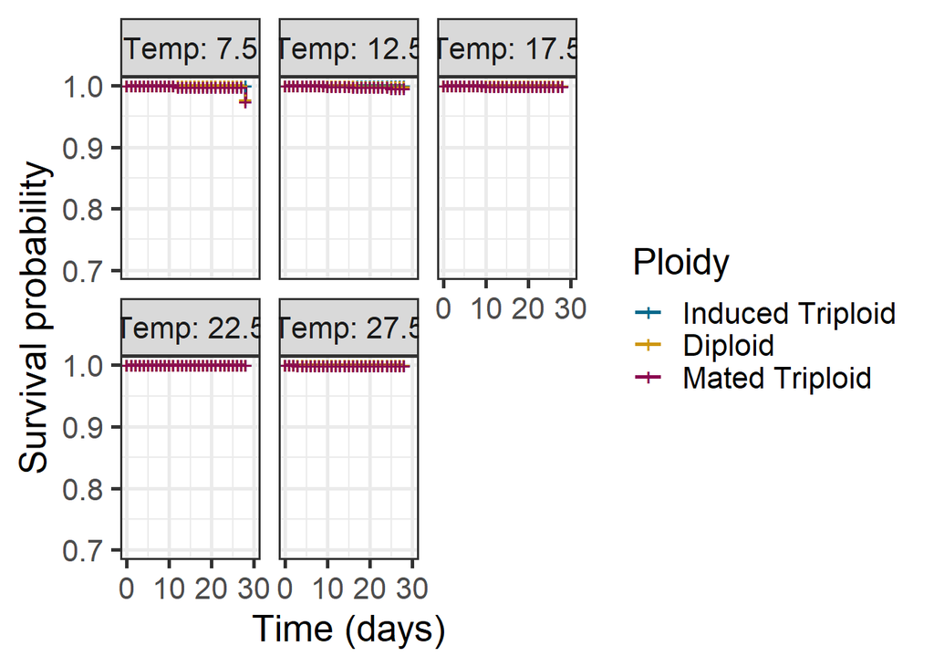

Plot the survival across tanks

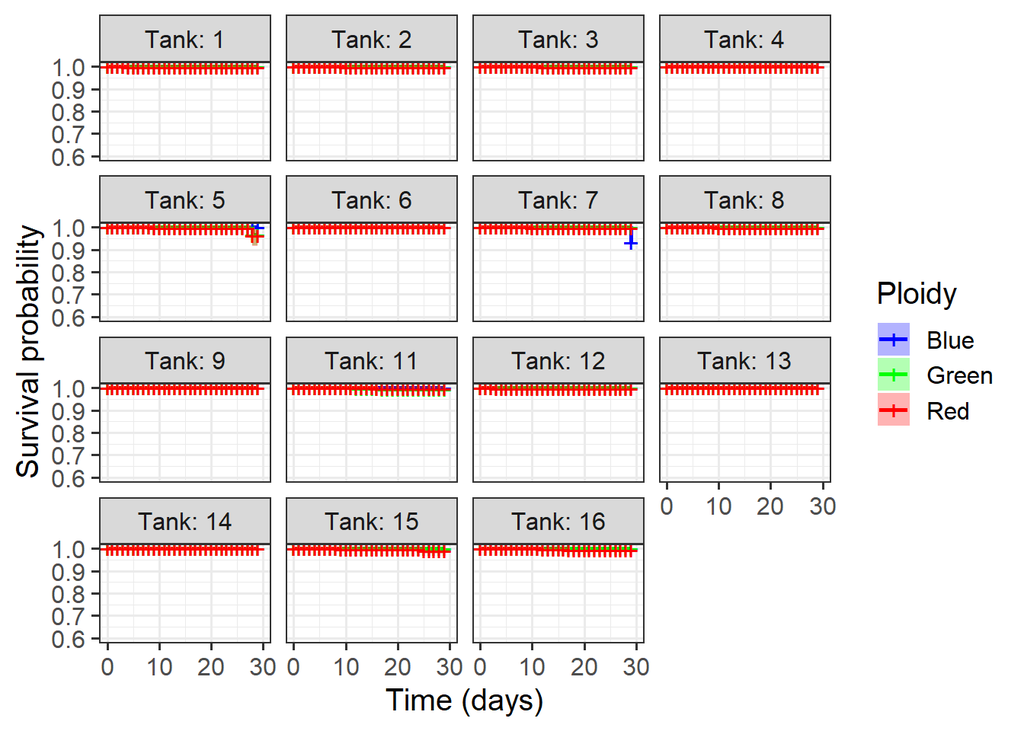

And finally the same plot, except faceted by Ploidy.

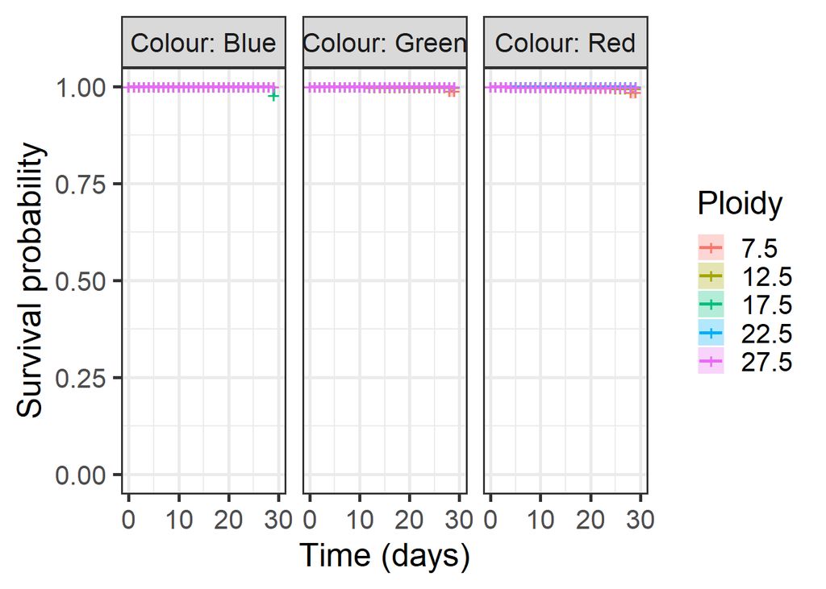

### Perform statistical analyses

Using the surv package in R I am going to analyse the data. First creating a Kaplan Meyer survival object and then examining the potential different models

```r
#Create a survival object for analyses
surv_temp <- with(survival_eventdat_temp, Surv(Time, event, type = "right"))#For some reason piping does not work here
#Create the survival models
K1_temp <- coxph(surv_temp ~ Temp , data = survival_eventdat_temp)
K2_temp <- coxph(surv_temp ~ Colour , data = survival_eventdat_temp)
K3_temp <- coxph(surv_temp ~ Colour + Temp, data = survival_eventdat_temp)
K4_temp <- coxph(surv_temp ~ Colour * Temp, data = survival_eventdat_temp)
summary(K1_temp)
```

```
## Call:
## coxph(formula = surv_temp ~ Temp, data = survival_eventdat_temp)
##
##   n= 40256, number of events= 20
##
##                coef  exp(coef)   se(coef)      z Pr(>|z|)
## Temp12.5 -2.869e-01  7.506e-01  5.401e-01 -0.531   0.5952
## Temp17.5 -7.035e-01  4.949e-01  6.124e-01 -1.149   0.2506
## Temp22.5 -1.899e+01  5.673e-09  4.653e+03 -0.004   0.9967
## Temp27.5 -1.397e+00  2.475e-01  7.906e-01 -1.766   0.0773 .
## ---
## Signif. codes:  0 '***' 0.001 '**' 0.01 '*' 0.05 '.' 0.1 ' ' 1
##
##          exp(coef) exp(-coef) lower .95 upper .95
## Temp12.5 7.506e-01  1.332e+00   0.26043     2.163
## Temp17.5 4.949e-01  2.021e+00   0.14901     1.643
## Temp22.5 5.673e-09  1.763e+08   0.00000       Inf
## Temp27.5 2.475e-01  4.041e+00   0.05255     1.165
##
## Concordance= 0.648  (se = 0.063 )
## Likelihood ratio test= 13.37  on 4 df,   p=0.01
## Wald test            = 3.69  on 4 df,   p=0.4
## Score (logrank) test = 10.18  on 4 df,   p=0.04
```

```r
summary(K2_temp)
```

```
## Call:
## coxph(formula = surv_temp ~ Colour, data = survival_eventdat_temp)
##
##   n= 40256, number of events= 20
##
##               coef exp(coef) se(coef)     z Pr(>|z|)
## ColourGreen 0.6981    2.0099   0.8660 0.806  0.42020
## ColourRed   1.9712    7.1793   0.7559 2.608  0.00912 **
## ---
## Signif. codes:  0 '***' 0.001 '**' 0.01 '*' 0.05 '.' 0.1 ' ' 1
##
##             exp(coef) exp(-coef) lower .95 upper .95
## ColourGreen     2.010     0.4975    0.3681     10.97
## ColourRed       7.179     0.1393    1.6317     31.59
##
## Concordance= 0.787  (se = 0.027 )
## Likelihood ratio test= 12.22  on 2 df,   p=0.002
## Wald test            = 10.17  on 2 df,   p=0.006
## Score (logrank) test = 12.83  on 2 df,   p=0.002
```

```r
summary(K3_temp)
```

```
## Call:
## coxph(formula = surv_temp ~ Colour + Temp, data = survival_eventdat_temp)
##
##   n= 40256, number of events= 20
##
##                   coef  exp(coef)   se(coef)      z Pr(>|z|)
## ColourGreen  7.013e-01  2.016e+00  8.660e-01  0.810  0.41806
## ColourRed    1.982e+00  7.259e+00  7.559e-01  2.622  0.00874 **
## Temp12.5    -2.927e-01  7.463e-01  5.401e-01 -0.542  0.58787
## Temp17.5    -7.124e-01  4.905e-01  6.124e-01 -1.163  0.24469
## Temp22.5    -1.900e+01  5.580e-09  4.652e+03 -0.004  0.99674
## Temp27.5    -1.405e+00  2.454e-01  7.906e-01 -1.777  0.07554 .
## ---
## Signif. codes:  0 '***' 0.001 '**' 0.01 '*' 0.05 '.' 0.1 ' ' 1
##
##             exp(coef) exp(-coef) lower .95 upper .95
## ColourGreen 2.016e+00  4.959e-01    0.3693    11.009
## ColourRed   7.259e+00  1.378e-01    1.6498    31.940
## Temp12.5    7.463e-01  1.340e+00    0.2589     2.151
## Temp17.5    4.905e-01  2.039e+00    0.1477     1.629
## Temp22.5    5.580e-09  1.792e+08    0.0000       Inf
## Temp27.5    2.454e-01  4.076e+00    0.0521     1.155
##
## Concordance= 0.834  (se = 0.032 )
## Likelihood ratio test= 25.74  on 6 df,   p=2e-04
## Wald test            = 13.99  on 6 df,   p=0.03
## Score (logrank) test = 23.16  on 6 df,   p=7e-04
```

```r
summary(K4_temp)
```

```
## Call:
## coxph(formula = surv_temp ~ Colour * Temp, data = survival_eventdat_temp)
##
##   n= 40256, number of events= 20
##
##                            coef  exp(coef)   se(coef)      z Pr(>|z|)
## ColourGreen           1.975e+01  3.768e+08  1.368e+04  0.001    0.999
## ColourRed             2.089e+01  1.178e+09  1.368e+04  0.002    0.999
## Temp12.5             -1.124e-07  1.000e+00  1.935e+04  0.000    1.000
## Temp17.5              1.974e+01  3.746e+08  1.368e+04  0.001    0.999
## Temp22.5             -1.142e-07  1.000e+00  1.935e+04  0.000    1.000
## Temp27.5             -1.237e-07  1.000e+00  1.935e+04  0.000    1.000
## ColourGreen:Temp12.5  1.269e-02  1.013e+00  1.935e+04  0.000    1.000
## ColourRed:Temp12.5   -4.162e-01  6.595e-01  1.935e+04  0.000    1.000
## ColourGreen:Temp17.5 -3.949e+01  7.084e-18  1.935e+04 -0.002    0.998
## ColourRed:Temp17.5   -2.087e+01  8.671e-10  1.368e+04 -0.002    0.999
## ColourGreen:Temp22.5 -1.975e+01  2.654e-09  2.370e+04 -0.001    0.999
## ColourRed:Temp22.5   -2.089e+01  8.491e-10  2.370e+04 -0.001    0.999
## ColourGreen:Temp27.5 -1.975e+01  2.654e-09  2.370e+04 -0.001    0.999
## ColourRed:Temp27.5   -1.124e+00  3.251e-01  1.935e+04  0.000    1.000
##
##                      exp(coef) exp(-coef) lower .95 upper .95
## ColourGreen          3.768e+08  2.654e-09         0       Inf
## ColourRed            1.178e+09  8.491e-10         0       Inf
## Temp12.5             1.000e+00  1.000e+00         0       Inf
## Temp17.5             3.746e+08  2.669e-09         0       Inf
## Temp22.5             1.000e+00  1.000e+00         0       Inf
## Temp27.5             1.000e+00  1.000e+00         0       Inf
## ColourGreen:Temp12.5 1.013e+00  9.874e-01         0       Inf
## ColourRed:Temp12.5   6.595e-01  1.516e+00         0       Inf
## ColourGreen:Temp17.5 7.084e-18  1.412e+17         0       Inf
## ColourRed:Temp17.5   8.671e-10  1.153e+09         0       Inf
## ColourGreen:Temp22.5 2.654e-09  3.768e+08         0       Inf
## ColourRed:Temp22.5   8.491e-10  1.178e+09         0       Inf
## ColourGreen:Temp27.5 2.654e-09  3.768e+08         0       Inf
## ColourRed:Temp27.5   3.251e-01  3.076e+00         0       Inf
##
## Concordance= 0.858  (se = 0.023 )
## Likelihood ratio test= 35.68  on 14 df,   p=0.001
## Wald test            = 5.08  on 14 df,   p=1
## Score (logrank) test = 35.4  on 14 df,   p=0.001
```

# pH

Read in the mortality data and prepare it for analysis. This involves changing the data from being only number of moralities at each sampling event to giving each individual a status. This is a lot of code to do not very much

```
## [1] 250
```

### Plot the data to visualise mortality between tanks

This plot shows pooled survival across pH treatments. This does not account for any random effects of tank that could influence survival. Just a starting point to get an overview of the data.

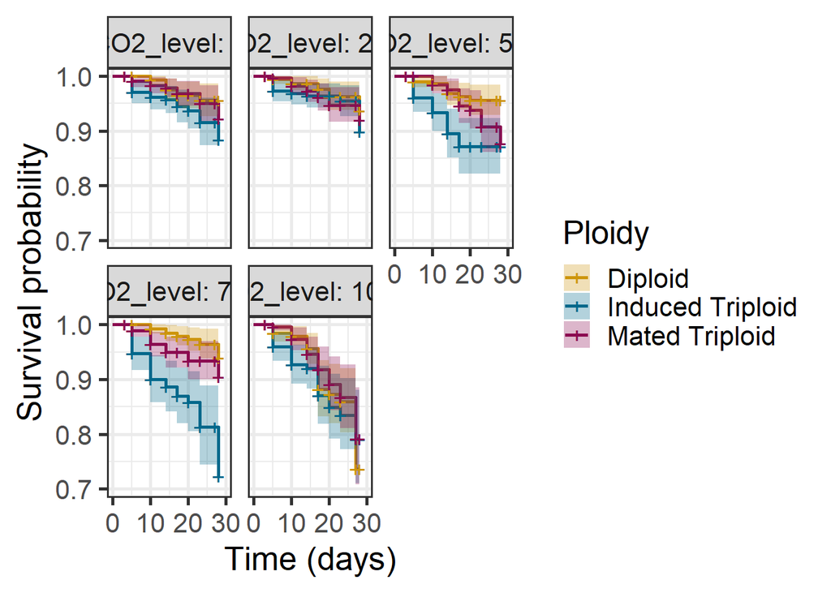

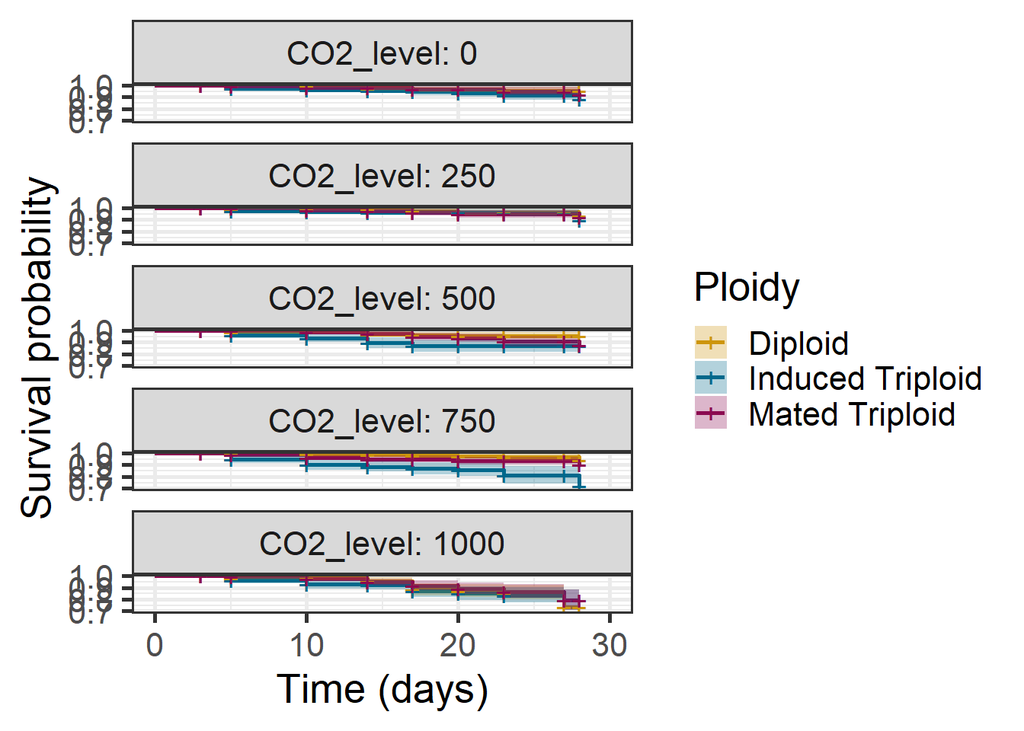

Here I am going to see how different ploidies reacted to the same pH treatment. The same data as above (i.e. pooled) but faceted by ploidy rather than CO2

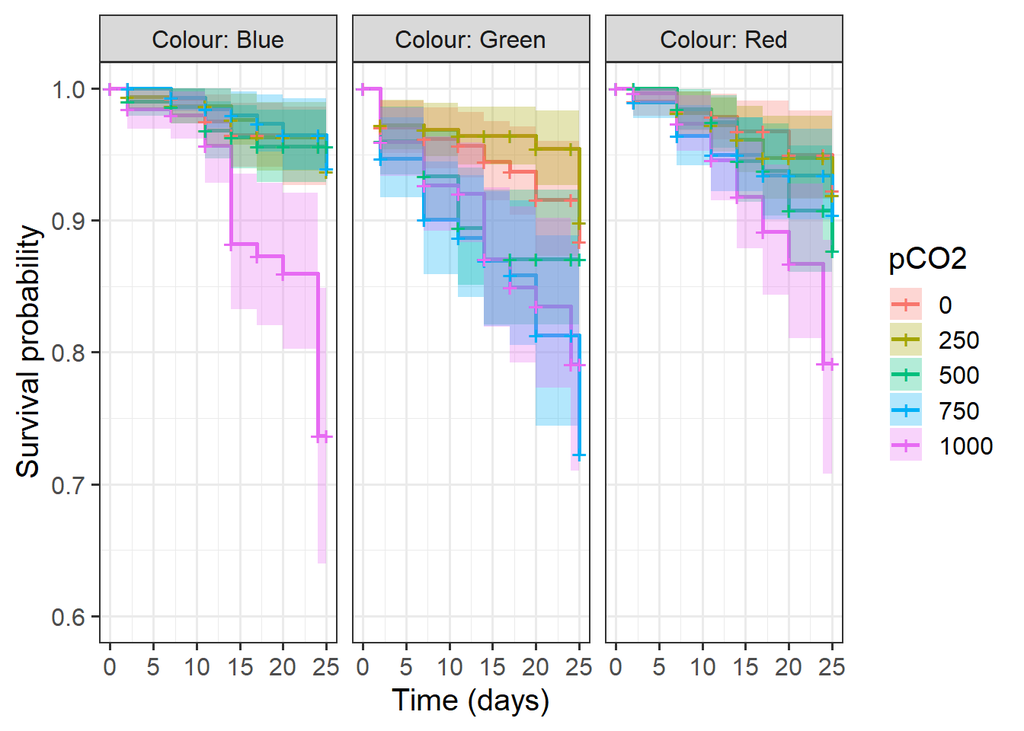

To see how survival varied across tanks this is a plot that shows the survival probability for each ploidy group across tanks.

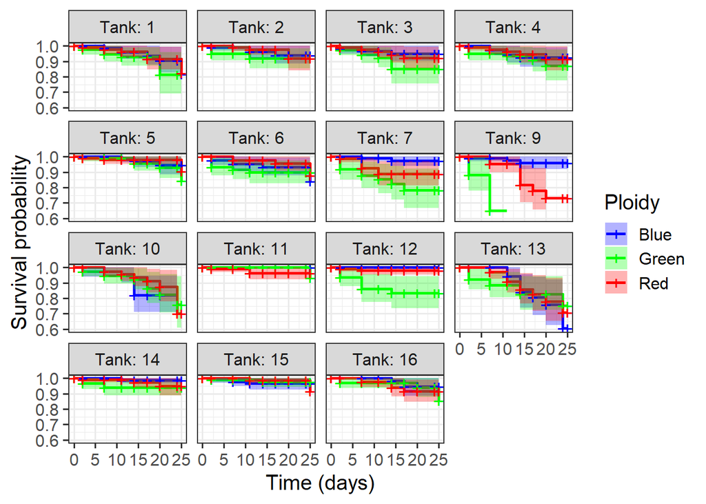

### Statistical analysis on the mortality data

First I am going to do a pooled analysis on all the data. This does not include a random effect of tank which I will include later. Using a cox proportional hazards model based on the analysis of McElhany.

```
## Call:
## coxph(formula = surv_pH ~ CO2_level, data = survival_eventdat_pH)
##
##   n= 4880, number of events= 250
##
##                  coef exp(coef) se(coef)      z Pr(>|z|)
## CO2_level250  -0.1124    0.8937   0.2376 -0.473   0.6360
## CO2_level500   0.3974    1.4880   0.2178  1.825   0.0680 .
## CO2_level750   0.4631    1.5890   0.2151  2.153   0.0313 *
## CO2_level1000  1.0478    2.8515   0.1997  5.247 1.55e-07 ***
## ---
## Signif. codes:  0 '***' 0.001 '**' 0.01 '*' 0.05 '.' 0.1 ' ' 1
##
##               exp(coef) exp(-coef) lower .95 upper .95
## CO2_level250     0.8937     1.1190     0.561     1.424
## CO2_level500     1.4880     0.6720     0.971     2.280
## CO2_level750     1.5890     0.6293     1.042     2.422
## CO2_level1000    2.8515     0.3507     1.928     4.218
##
## Concordance= 0.6  (se = 0.019 )
## Likelihood ratio test= 44.28  on 4 df,   p=6e-09
## Wald test            = 45.87  on 4 df,   p=3e-09
## Score (logrank) test = 49.26  on 4 df,   p=5e-10
```

```
## Call:
## coxph(formula = surv_pH ~ Colour, data = survival_eventdat_pH)
##
##   n= 4880, number of events= 250
##
##               coef exp(coef) se(coef)     z Pr(>|z|)
## ColourGreen 0.8294    2.2920   0.1583 5.240  1.6e-07 ***
## ColourRed   0.2774    1.3197   0.1694 1.638    0.101
## ---
## Signif. codes:  0 '***' 0.001 '**' 0.01 '*' 0.05 '.' 0.1 ' ' 1
##
##             exp(coef) exp(-coef) lower .95 upper .95
## ColourGreen     2.292     0.4363    1.6807     3.126
## ColourRed       1.320     0.7577    0.9469     1.839
##
## Concordance= 0.617  (se = 0.018 )
## Likelihood ratio test= 30.26  on 2 df,   p=3e-07
## Wald test            = 30.77  on 2 df,   p=2e-07
## Score (logrank) test = 32.15  on 2 df,   p=1e-07
```

```
## Call:
## coxph(formula = surv_pH ~ Colour + CO2_level, data = survival_eventdat_pH)
##
##   n= 4880, number of events= 250
##
##                  coef exp(coef) se(coef)      z Pr(>|z|)
## ColourGreen    0.8437    2.3250   0.1587  5.315 1.07e-07 ***
## ColourRed      0.2657    1.3044   0.1695  1.568   0.1169
## CO2_level250  -0.1288    0.8791   0.2376 -0.542   0.5877
## CO2_level500   0.4313    1.5392   0.2179  1.979   0.0478 *
## CO2_level750   0.5234    1.6877   0.2154  2.430   0.0151 *
## CO2_level1000  1.0459    2.8460   0.1997  5.237 1.63e-07 ***
## ---
## Signif. codes:  0 '***' 0.001 '**' 0.01 '*' 0.05 '.' 0.1 ' ' 1
##
##               exp(coef) exp(-coef) lower .95 upper .95
## ColourGreen      2.3250     0.4301    1.7033     3.174
## ColourRed        1.3044     0.7666    0.9357     1.818
## CO2_level250     0.8791     1.1375    0.5518     1.401
## CO2_level500     1.5392     0.6497    1.0042     2.359
## CO2_level750     1.6877     0.5925    1.1065     2.574
## CO2_level1000    2.8460     0.3514    1.9241     4.209
##
## Concordance= 0.666  (se = 0.019 )
## Likelihood ratio test= 75.7  on 6 df,   p=3e-14
## Wald test            = 77.84  on 6 df,   p=1e-14
## Score (logrank) test = 82.58  on 6 df,   p=1e-15
```

```
## Call:
## coxph(formula = surv_pH ~ Colour * CO2_level, data = survival_eventdat_pH)
##
##   n= 4880, number of events= 250
##
##                               coef exp(coef) se(coef)      z Pr(>|z|)
## ColourGreen                0.82126   2.27336  0.41223  1.992 0.046347 *
## ColourRed                  0.22406   1.25115  0.44947  0.499 0.618125
## CO2_level250              -0.01695   0.98320  0.47141 -0.036 0.971323
## CO2_level500               0.14435   1.15529  0.45947  0.314 0.753398
## CO2_level750              -0.16465   0.84819  0.48591 -0.339 0.734719
## CO2_level1000              1.44267   4.23197  0.38498  3.747 0.000179 ***
## ColourGreen:CO2_level250  -0.35439   0.70160  0.59831 -0.592 0.553641
## ColourRed:CO2_level250     0.13276   1.14198  0.62966  0.211 0.833002
## ColourGreen:CO2_level500   0.42057   1.52282  0.55984  0.751 0.452518
## ColourRed:CO2_level500     0.31483   1.37003  0.60376  0.521 0.602051
## ColourGreen:CO2_level750   1.07460   2.92882  0.57397  1.872 0.061176 .
## ColourRed:CO2_level750     0.59714   1.81692  0.62745  0.952 0.341249
## ColourGreen:CO2_level1000 -0.67386   0.50974  0.49398 -1.364 0.172525
## ColourRed:CO2_level1000   -0.40289   0.66839  0.52984 -0.760 0.447018
## ---
## Signif. codes:  0 '***' 0.001 '**' 0.01 '*' 0.05 '.' 0.1 ' ' 1
##
##                           exp(coef) exp(-coef) lower .95 upper .95
## ColourGreen                  2.2734     0.4399    1.0134     5.100
## ColourRed                    1.2512     0.7993    0.5185     3.019
## CO2_level250                 0.9832     1.0171    0.3903     2.477
## CO2_level500                 1.1553     0.8656    0.4694     2.843
## CO2_level750                 0.8482     1.1790    0.3273     2.198
## CO2_level1000                4.2320     0.2363    1.9900     9.000
## ColourGreen:CO2_level250     0.7016     1.4253    0.2172     2.267
## ColourRed:CO2_level250       1.1420     0.8757    0.3324     3.923
## ColourGreen:CO2_level500     1.5228     0.6567    0.5083     4.562
## ColourRed:CO2_level500       1.3700     0.7299    0.4196     4.474
## ColourGreen:CO2_level750     2.9288     0.3414    0.9509     9.021
## ColourRed:CO2_level750       1.8169     0.5504    0.5312     6.215
## ColourGreen:CO2_level1000    0.5097     1.9618    0.1936     1.342
## ColourRed:CO2_level1000      0.6684     1.4961    0.2366     1.888
##
## Concordance= 0.673  (se = 0.018 )
## Likelihood ratio test= 93.35  on 14 df,   p=9e-14
## Wald test            = 91.04  on 14 df,   p=2e-13
## Score (logrank) test = 105  on 14 df,   p=5e-16
```

I am going to add a random effect of tank here to assess inter tank variation. I am using the frailtyEM package (Balan and Putter 2019) as in McElhany crab survival analysis. I am going to include treatment and ploidy as fixed effects tank as a random effect. I have no idea if this is correct or how to interpret it.

```r
survival_eventdat_pH1 <- survival_eventdat_pH %>% mutate(across(c("CO2_level","Tank", "Colour"), as.factor))
survival_eventdat_pH1$Time <- as.numeric(survival_eventdat_pH1$Time)
survival_eventdat_pH1$Time <- survival_eventdat_pH1$Time+1
pH_frailty_fit <- survival_eventdat_pH1 %>% emfrail(Surv(Time, event, type = "right") ~ CO2_level*Colour + cluster(Tank),
distribution = emfrail_dist(dist = "gamma"),
data = .)
```

# DO

## Mortality

Read in the mortality data, and format it so that I can run survival analyses.

```r
DO_survivors <- read.csv(here("Data", "DO", "DO__survivors.csv"))
DO_survivors$Tank <- as.factor(DO_survivors$Tank)
DO_tank_assignments <- read.csv(here("Data", "DO", "DO_tank_assignments.csv"))
#Uncount each of the rows in the first survivor colum
individ_mortdat_DO <- DO_survivors %>%
  select(1:3) %>%
  uncount(weights = Surv_1)
individ_mortdat_DO$ID <- rep(1:30, length.out = nrow(individ_mortdat_DO))#Add an ID column so each individual has a unique ID

individ_mortdat_DO$status_Surv_0 <- 0

#Create a df to store all survival event data for analyes
survival_eventdat_DO <- individ_mortdat_DO

#create a for loop that gives all survivors a status across all
for (i in 3:34) {
  # Extract the current column name
  current_column_name <- colnames(DO_survivors)[i]

  # Remove "Survivors_" from the current column name
  stripped_column_name <- current_column_name

  # Create a new column name based on the stripped current column name
  new_column_name <- paste0("status_", stripped_column_name)

  # Uncount the specified column
  survivors_column <- DO_survivors[c(1:2, i)] %>%
    mutate(weights = as.numeric(get(current_column_name))) %>%
    uncount(weights)

  # Add an ID column from 1 to 15
  survivors_column <- survivors_column %>%
    group_by(across(c(1, 2))) %>%
    mutate(ID = row_number()) %>%
    ungroup()

  # Add a status column to indicate that these individuals are alive
  survivors_column[[new_column_name]] <- 0

  # Join the data frames
  survival_eventdat_DO <- left_join(survival_eventdat_DO, survivors_column, by = c("Tank", "Colour", "ID"))
}

#Select the columns that status at the begining
survival_eventdat_DO <- survival_eventdat_DO %>% select(-starts_with("Surv"))
#Now need to pivot longer for survival plots
survival_eventdat_DO <- survival_eventdat_DO %>% pivot_longer(cols= -c(1:3), names_to = "Time", values_to = "Status")
#Remove the status from the time column
survival_eventdat_DO <- survival_eventdat_DO %>% mutate(Time = gsub("status_Surv_", "", Time))
#Add 1 where there is a NA
survival_eventdat_DO$Status[is.na(survival_eventdat_DO$Status)] <- 1
#Only keep the first instance of 1 (An individual can only die once - Cue James Bond music).
survival_eventdat_DO <- survival_eventdat_DO %>%
  group_by(Tank, Colour, ID) %>%
  filter(row_number() <= which.max(Status == 1) | sum(Status == 1) == 0) %>% ungroup()
#Make sure that the sum of mortality events actually matches the number of mortalities. In the DOerature experiment this was 20
survival_eventdat_DO$event <- survival_eventdat_DO$Status
survival_eventdat_DO$Time <- as.numeric(survival_eventdat_DO$Time)
sum(survival_eventdat_DO$Status)
```

```
## [1] 73
```

```r
#Merge the file with the list of treatment tanks
survival_eventdat_DO <- merge(survival_eventdat_DO, DO_tank_assignments, by = "Tank")
```

Plot the mortality between tanks faceted by DO level

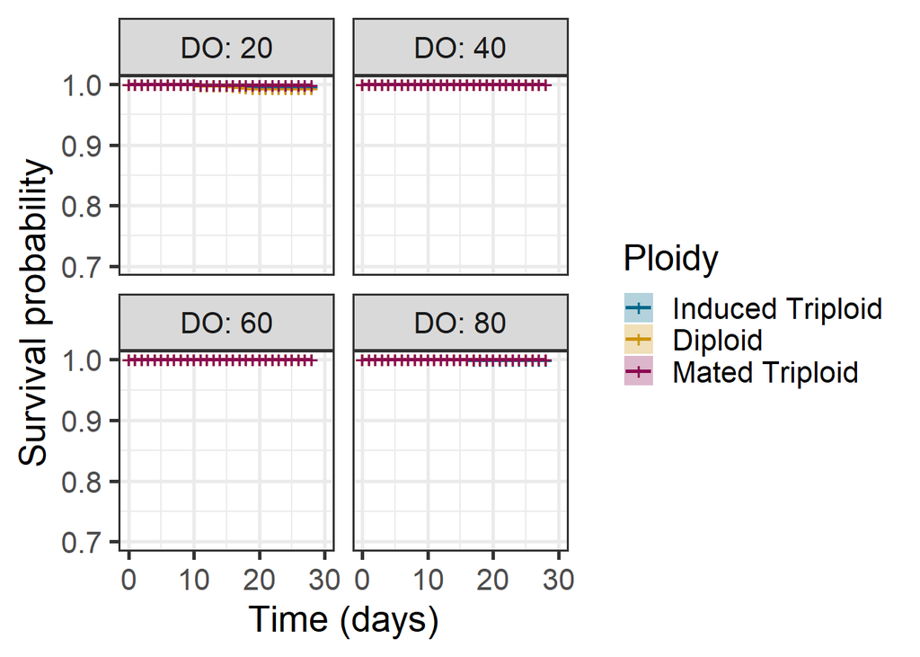

```r
survival_eventdat_DO$DO <- factor(survival_eventdat_DO$DO, levels = c("20", "40", "60", "80", "100"))#Set#Order the facets
pooled_site_survplot_DO_pooled <- survival_eventdat_DO %>% filter(Time <= 28) %>%
  filter(DO != 100) %>%
 ggsurvplot_facet(survfit(Surv(Time, event, type = "right") ~ Colour , data = .),
            facet.by = "DO",
            data = .,
            risk.table = FALSE, pval = FALSE, conf.int = TRUE,
            legend.labs = c("Induced Triploid","Diploid", "Mated Triploid"),
            xlab = "Time (days)",
             ylim = c(0.7, 1),
            legend.strata = FALSE,
            legend.title = "Ploidy")+
  theme_bw(base_size = 20)+
  labs(legend = "ploidy")+
  scale_color_manual(values = c("#00688B", "#CD950C", "#8B0A50"))+
  scale_fill_manual(values = c("#00688B", "#CD950C", "#8B0A50"))
pooled_site_survplot_DO_pooled
```

```r
#Do it long to see the comparisons
longpooled_site_survplot_DO_pooled <- pooled_site_survplot_DO_pooled <- survival_eventdat_DO %>% filter(Time <= 28) %>%
  filter(DO != 100) %>%
 ggsurvplot_facet(survfit(Surv(Time, event, type = "right") ~ Colour , data = .),
            facet.by = "DO",
            data = .,
            risk.table = FALSE, pval = FALSE, conf.int = TRUE,
            legend.labs = c("Induced Triploid","Diploid", "Mated Triploid"),
            xlab = "Time (days)",
             ylim = c(0.7, 1),
            legend.strata = FALSE,
            ncol = 1)+
  theme_bw(base_size = 20)+
  labs(legend = "ploidy")+
  scale_color_manual(values = c("#00688B", "#CD950C", "#8B0A50"))+
  scale_fill_manual(values = c("#00688B", "#CD950C", "#8B0A50"))



#grid.arrange(longpooled_site_survplot_temp_pooled,longpooled_site_survplot_DO_pooled, longpooled_site_survplot_pH_pooled, ncol = 3)
```

Facet by Tank

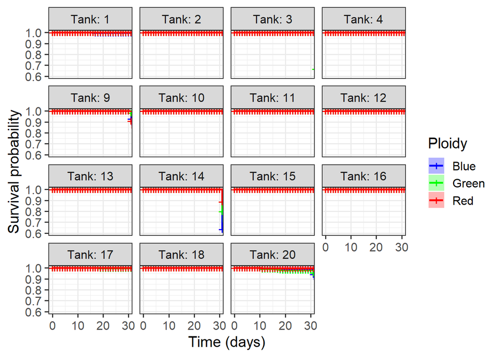

```r
pooled_site_survplot_DO_pooled_tank <- survival_eventdat_DO %>%
 ggsurvplot_facet(survfit(Surv(Time, event, type = "right") ~ Colour , data = .),
            facet.by = "Tank",
            data = .,
            risk.table = FALSE, pval = FALSE, conf.int = TRUE,
            #legend.labs = c("Diploid", "Induced Triploid", "Mated Triploid"),
            xlab = "Time (days)",
             ylim = c(0.6, 1),
            legend.strata = FALSE,
            legend.title = "Ploidy")+
  theme_bw(base_size = 15)+
  labs(legend = "ploidy")+
  scale_color_manual(values = c("blue", "green", "red"))+
  scale_fill_manual(values = c("blue", "green", "red"))
pooled_site_survplot_DO_pooled_tank
```

Facet by ploidy